# Seminar 8

In this class we will:

1. Use the Black-Scholes equation to price an option  
2. Simulate option prices with Monte Carlo  
3. Experiment with different simulation sizes  
4. Use analytical and simulation methods to get VaR  
5. Calculate VaR for the option  
6. Calculate VaR for a portfolio of stock and option

## Using Black-Scholes to price an option

We will define a `bs()` function that takes a strike price, $K$, the price of the underlying asset $P$, the annual risk-free interest rate, $r$, annual volatiliry $\sigma$, and the time to maturity. This function can return the price of a European put or call option (put by default) will return the price of a European put option. We will focus only on put options in this section, but the process is analogous for call options:

```r
# Black-Scholes function
bs <- function(K, P, r, sigma, Maturity, type = "Put"){
    d1 <- (log(P/K) + (r+0.5*sigma^2/2)*(Maturity))/(sigma*sqrt(Maturity))
    d2 <- d1 - sigma*sqrt(Maturity)
    Call <- P*pnorm(d1) - K*exp(-r*(Maturity))*pnorm(d2)
    Put <- K*exp(-r*(Maturity))*pnorm(-d2) - P*pnorm(-d1)
    if (type == "Put") {
        return(Put)
        } else if (type == "Call") {
        return(Call)
    } else {
        return("Not a valid type")
    }
}
```

We will work with the JP Morgan stock. Let's first load it into our environment and estimate its volatility:

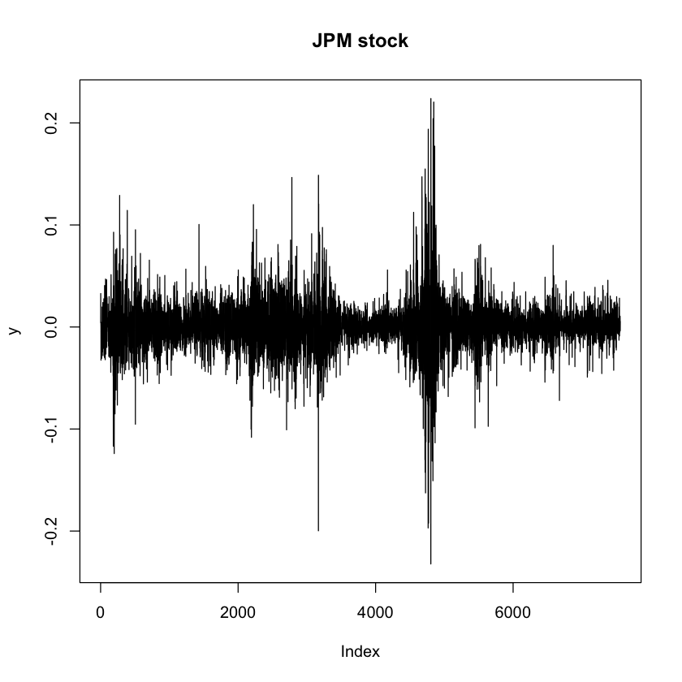

```r
# Load JPM stock
load("Y.RData")
y <- Y$JPM
plot(y, type = "l", main = "JPM stock")
```

We need to scale the standard deviation of the stock by $\sqrt{250}$ to get the estimated yearly volatility. We use 250 because it is the number of *trading days* in a year (Monday - Friday). Note that this is different from the *calendar days*, which are 365. The latter are used when dealing with the yearly risk-free interest rate.

```r
# Estimating volatility with returns
n <- length(y)
sigma <- sd(y)*sqrt(250)
sigma
```

0.370395546800258

In order to use the Black-Scholes formula, we need the underlying price of the asset. We will load the `PRC.RData` file and get the last observation available for JP Morgan:

```r
# Getting the last price available for JPM
load("PRC.RData")
P <- tail(PRC$JPM,1)
P
```

139.39999

We need to make assumptions on the risk-free rate and necessary parameters for an option. We will assume the risk-free rate is $r=3\%$, the maturity is 1 year, and the strike price is $K=100$:

```r
# Assuming the necessary parameters
r <- 0.03
Maturity <- 1
K <- 100
```

Now we can use the `bs()` function we defined to price the option:

```r
# Calculating the option price
put <- bs(K = K, P = P, r = r, sigma = sigma, Maturity = Maturity)
put
```

3.65571347437609

#### Option price as a function of the Underlying stock price

We have used the last price observed to calculate the price of the option.

However, we can do a plot of the option price as a function of the underlying stock price. To do so, we will create a variable called `x` that will contain a sequence of values between 50 and 150. You can think of this variable as the x-axis of the plot. These are all the possible underlying prices we want will consider. We will use the function `seq()` with a length of 1000. Then, we will call the option `bs()` with the variable `x` as the argument `P`, for underlying price, and the result will be a vector of length 1000, with the option price for each value in the sequence `x`. Finally, we plot them together:

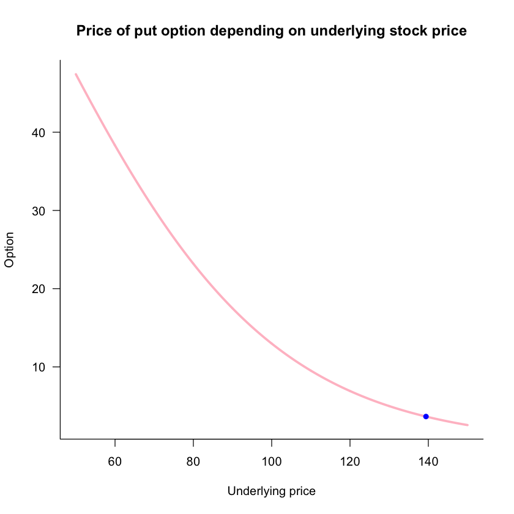

```r
# Option price as a function of underlying stock price

# Sequence of underlying prices
x <- seq(50, 150, length = 1000)

# Plot option price
plot(x, bs(K = K, P = x, r = r, sigma = sigma, Maturity = Maturity),
    type = "l", ylab = "Option", xlab = "Underlying price", lwd = 3, col = "pink", las = 1,
    bty = "l", main = "Price of put option depending on underlying stock price")

# Add a point for the observed price
points(P, bs(K=K, P=P, r=r, sigma=sigma, Maturity = Maturity),
       pch = 16, col="blue")
```

We can see the put price is decreasing on the underlying price, and convex. We repeat the same procedure using a sequence for the Strike price, risk-free rate, volatility, and time to maturity:

#### Option price as a function of the Strike price

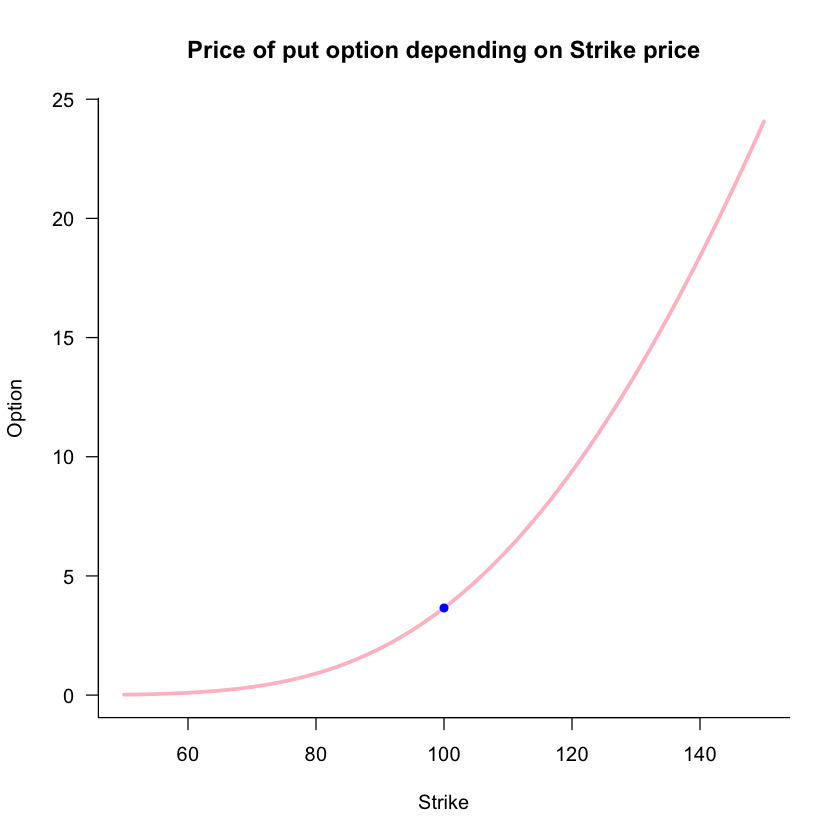

```r
# Option price as a function of Strike price

# Sequence of Strike
x <- seq(50, 150, length = 1000)

# Plot option price
plot(x, bs(K = x, P = P, r = r, sigma = sigma, Maturity = Maturity),
    type = "l", ylab = "Option", xlab = "Strike", lwd = 3, col = "pink", las = 1,
    bty = "l", main = "Price of put option depending on Strike price")

# Add a point for the observed price
points(K, bs(K=K, P=P, r=r, sigma=sigma, Maturity = Maturity),
       pch = 16, col="blue")
```

The price of the put option is increasing and convex in the Strike price.

#### Option price as a function of the Risk-free rate

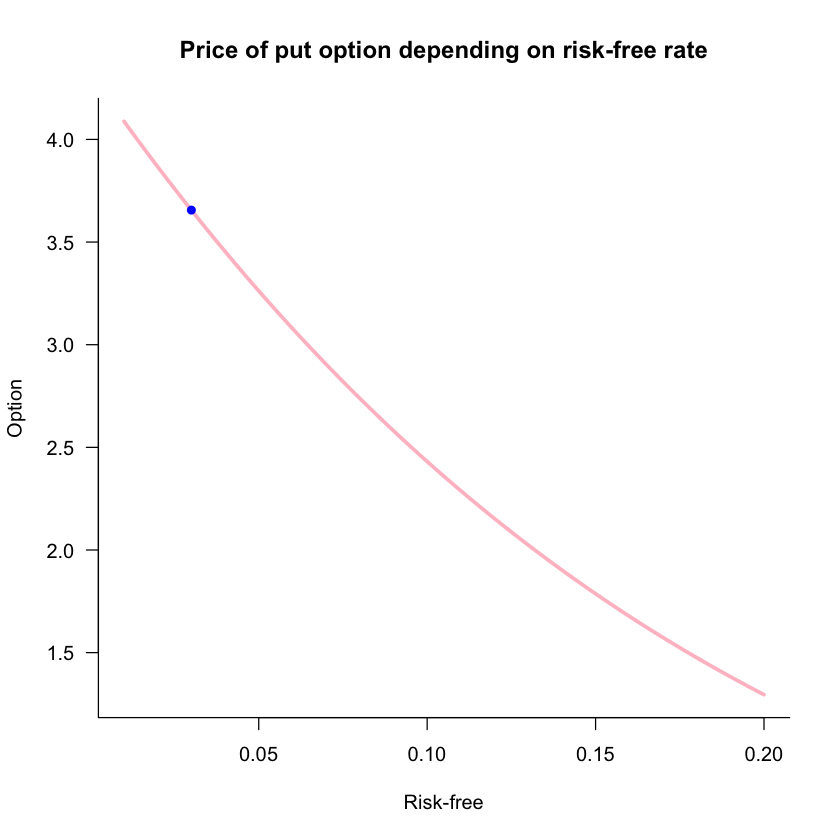

```r
# Option price as a function of risk-free rate

# Sequence of risk-free
x <- seq(0.01, 0.2, length = 1000)

# Plot option price
plot(x, bs(K = K, P = P, r = x, sigma = sigma, Maturity = Maturity),
    type = "l", ylab = "Option", xlab = "Risk-free", lwd = 3, col = "pink", las = 1,
    bty = "l", main = "Price of put option depending on risk-free rate")

# Add a point for the observed price
points(r, bs(K=K, P=P, r=r, sigma=sigma, Maturity = Maturity),
       pch = 16, col="blue")
```

The price of the put option is decreasing and convex in the risk-free rate.

#### Option price as a function of volatility

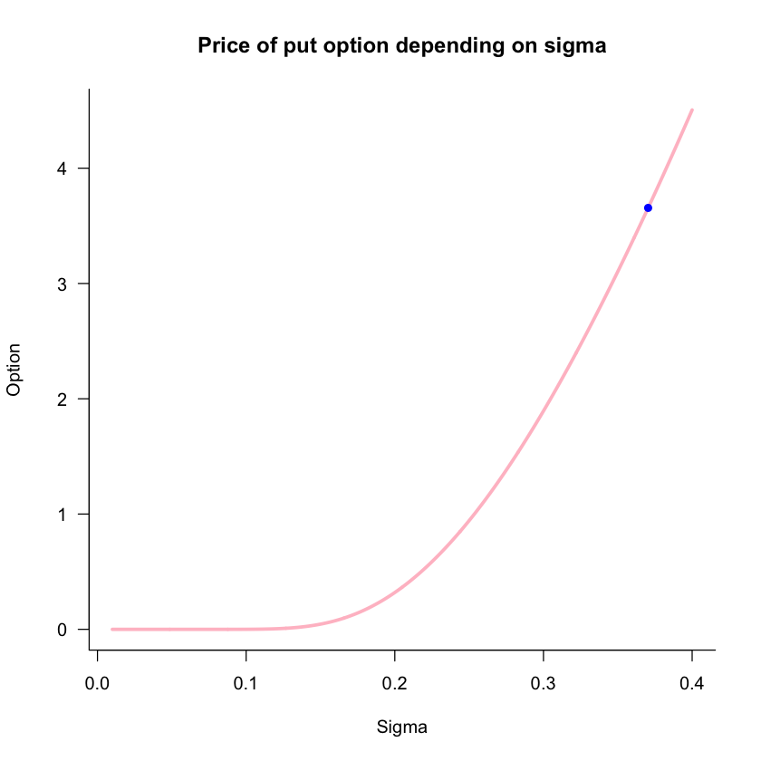

```r
# Option price as a function of sigma

# Sequence of sigma
x <- seq(0.01, 0.4, length = 1000)

# Plot option price
plot(x, bs(K = K, P = P, r = r, sigma = x, Maturity = Maturity),
    type = "l", ylab = "Option", xlab = "Sigma", lwd = 3, col = "pink", las = 1,
    bty = "l", main = "Price of put option depending on sigma")

# Add a point for the observed price
points(sigma, bs(K=K, P=P, r=r, sigma=sigma, Maturity = Maturity),
       pch = 16, col="blue")
```

The price of the option is increasing and convex in sigma, with the presence of exponential growth.

#### Option price as a function of Maturity

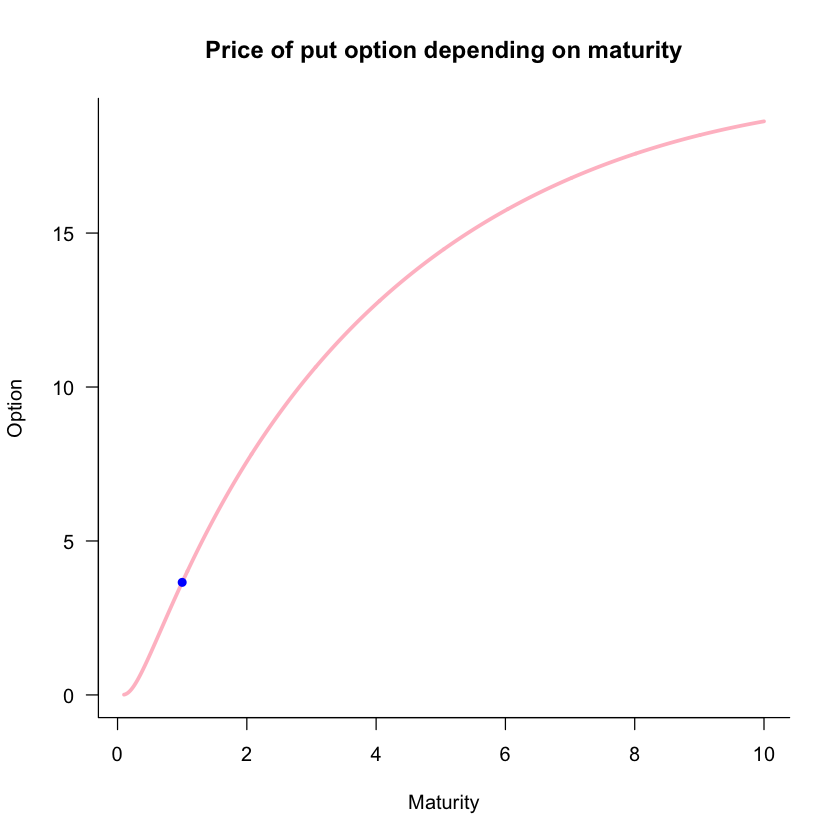

```r
# Option price as a function of Maturity

# Sequence of maturity
x <- seq(0.1, 10, length = 1000)

# Plot option price
plot(x, bs(K = K, P = P, r = r, sigma = sigma, Maturity = x),
    type = "l", ylab = "Option", xlab = "Maturity", lwd = 3, col = "pink", las = 1,
    bty = "l", main = "Price of put option depending on maturity")

# Add a point for the observed price
points(Maturity, bs(K=K, P=P, r=r, sigma=sigma, Maturity = Maturity),
       pch = 16, col="blue")
```

The option price is increasing and concave in maturity.

## Using Monte-Carlo simulation to price an option

We can use a random number generator to simulate the price of an option:

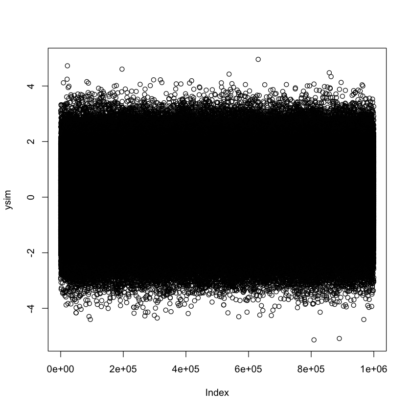

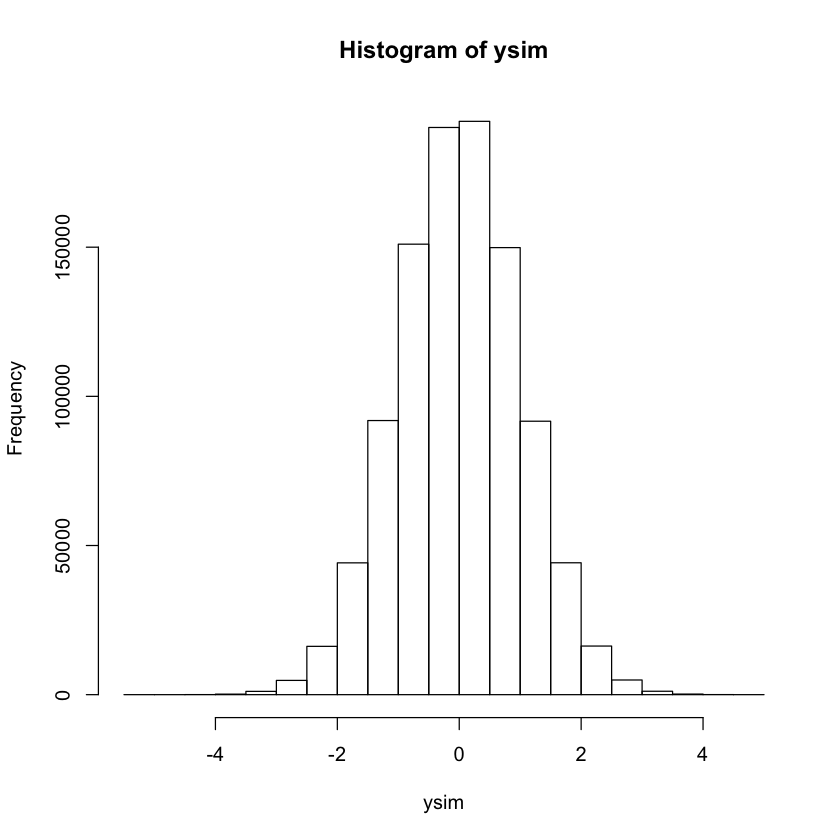

```r
# Using Monte Carlo

# Simulations
S <- 1e6

# Set seed for replicability
set.seed(420)

# Get 1e6 simulations from a standard normal
ysim <- rnorm(S)

# Plot the random numbers
plot(ysim)
hist(ysim)
```

Remember we need to apply a **log-normal correction** in the simulation. To do so, we subtract $\frac{1}{2}\sigma^2$ from the simulated stock returns. By default, `rnorm()` uses a standard normal, we would also need to scale for the desired variance:

```r
# Centering in the desired mean and changing the variance
ysim <- ysim - 0.5*sigma^2*Maturity
ysim <- ysim*sigma*sqrt(Maturity)
```

We can directly specify this in `rnorm()` to account for the variance and log-normal correction:

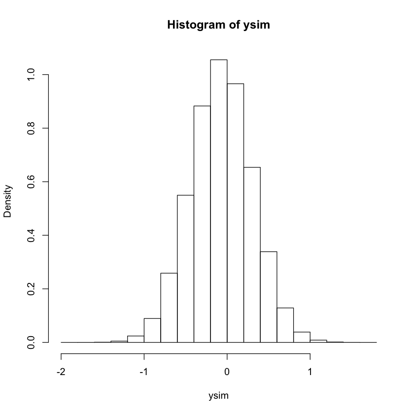

```r
# Specifying mean/sd in rnorm directly
set.seed(420)
ysim <- rnorm(S, mean=-0.5*sigma^2*Maturity, sd = sigma*sqrt(Maturity))

# Histogram
hist(ysim, probability = TRUE)
```

Now we can simulate the no-arbitrage future prices of the stock:

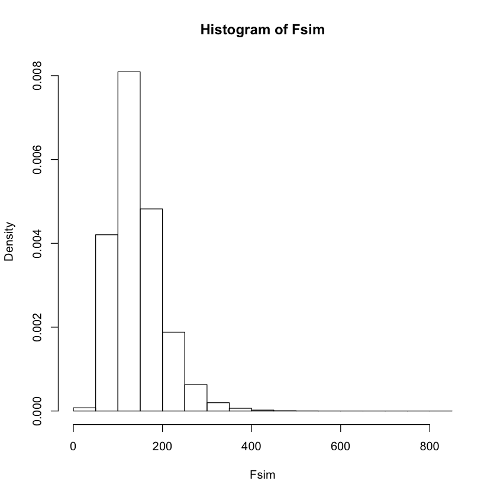

```r
# Simulating future prices of stock
Fsim <- P*exp(r*Maturity)*exp(ysim)
hist(Fsim, probability = TRUE)
```

To simulate the price of the put option, we subtract the simulated prices of the underlying stock from the strike price, and replace it with 0 if negative, since the option would not be executed:

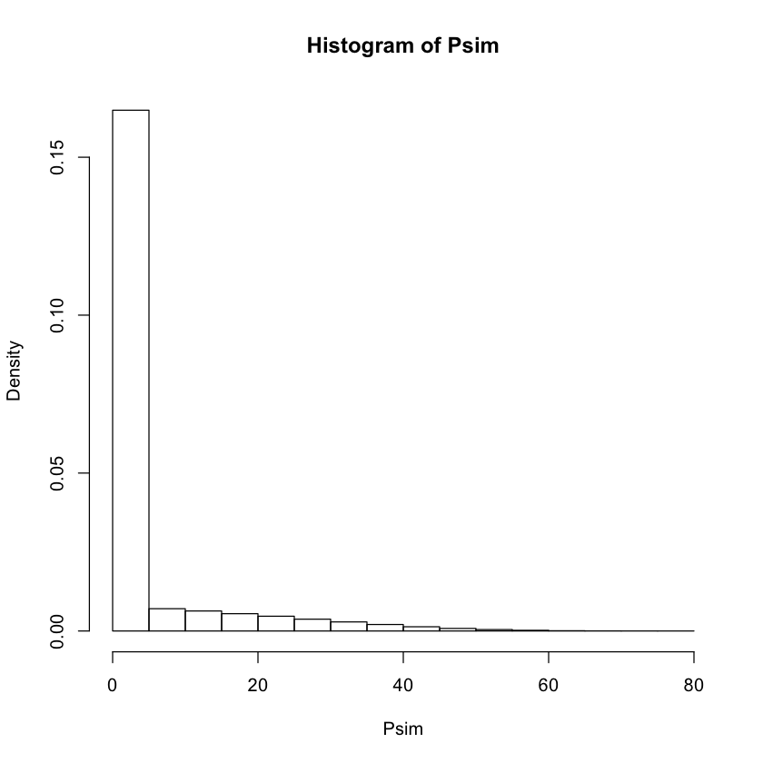

```r
# Simulated price of stock
Psim <- K - Fsim

# Replacing negatives with zero
Psim[Psim<0] <- 0

# Histogram
hist(Psim, probability = TRUE)
```

The histogram has a peak in 0 due to all the cases when the put option is not executed. Now let's compare the price we obtained analytically using the Black-Scholes formula and the price obtained through Simulation:

```r
# Comparing analytical and simulation prices
Psim <- Psim*exp(-r*Maturity)

cat("Analytic price:", put, "\n",
    "Simulation price:", mean(Psim))
```

```
Analytic price: 3.655713
 Simulation price: 3.68599
```

## Experimenting using Simulation sizes

We can repeat the experiment as a function of the simulation size:

```r
# Experimenting using Simulation sizes
# For a given simulation size S, say S = 100
S <- 100

# Set the seed, e.g. 100
set.seed(100)

# Do the simulation
ysim <- rnorm(S,
             mean = -0.5*sigma^2*Maturity,
             sd = sigma*sqrt(Maturity))

# Get the simulated paths
Fsim <- P*exp(r*Maturity)*exp(ysim)

# Subtract from strike price and only exercise the option if its positive
Psim <- K - Fsim
Psim[Psim<0] <- 0
Psim <- Psim * exp(-r*Maturity)

round(mean(Psim),4)
```

3.702

Now let's create a function `Sim()` that does these steps for us:

```r
# Function on simulation size and seed
Sim <- function(S, seed = 999, message = TRUE){
    set.seed(seed)
    ysim <- rnorm(S,
                  mean = -0.5*sigma^2*Maturity,
                  sd = sigma*sqrt(Maturity))
    Fsim <- P*exp(r*Maturity)*exp(ysim)
    Psim <- K-Fsim
    Psim[Psim<0] <- 0
    Psim <- Psim*exp(-r*Maturity)
    if (message) {
        cat("**************************", "\n",
            "Number of simulations:", S, "\n",
           "Using seed:", seed, "\n",
           "Simulated price:", mean(Psim),"\n",
           "\n")
    }
    return(mean(Psim))
}
```

Let's see how the simulated price evolves with simulation size for our stock:

```r
# Different simulation sizes
x <- c(10, 100, 1000, 10000, 100000, 1000000)
for(size in x){
    Sim(size, seed = 420)
}
```

```
 Number of simulations: 10
 Using seed: 420
 Simulated price: 5.842383

 Number of simulations: 100
 Using seed: 420
 Simulated price: 5.005495

 Number of simulations: 1000
 Using seed: 420
 Simulated price: 3.667088

 Number of simulations: 10000
 Using seed: 420
 Simulated price: 3.500996

 Number of simulations: 1e+05
 Using seed: 420
 Simulated price: 3.659979

 Number of simulations: 1e+06
 Using seed: 420
 Simulated price: 3.68599
```

We can make a plot to visually see how we converge to the analytic price as simulation size increases:

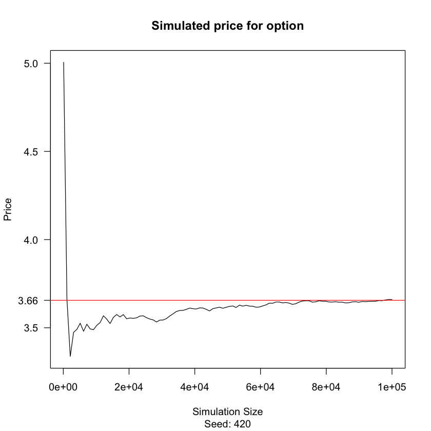

```r
# Plot converge of price
seed <- 420

# Sequence of simulations
x <- seq(100, 100000, length = 100)

# Simulation price of each
P_sim <- sapply(x, Sim, seed = seed, message = FALSE)

# Plot
plot(x, P_sim, type = "l", main = "Simulated price for option", sub = paste0("Seed: ", seed),
    xlab = "Simulation Size", ylab = "Price", las = 1)

# Add horizontal line on Analytic price
abline(h = put, col = "red")
axis(2, at = put, label = round(put,2), las = 1)
```

We can look at other seeds:

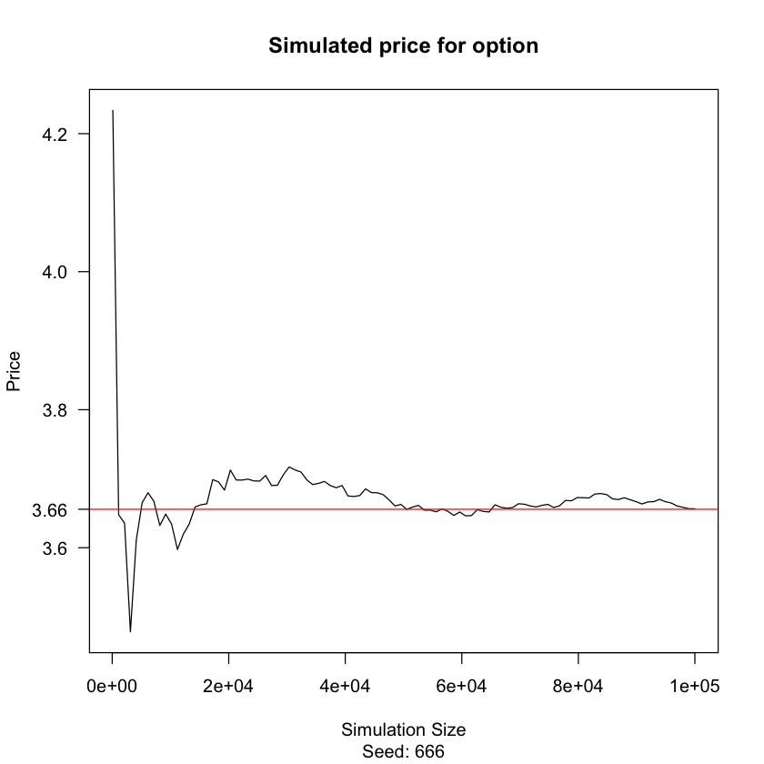

```r
# Different seeds

seed <- 666

# Simulation price of each
P_sim <- sapply(x, Sim, seed = seed, message = FALSE)

# Plot
plot(x, P_sim, type = "l", main = "Simulated price for option", sub = paste0("Seed: ", seed),
    xlab = "Simulation Size", ylab = "Price", las = 1)

# Add horizontal line on Analytic price
abline(h = put, col = "red")
axis(2, at = put, label = round(put,2), las = 1)
```

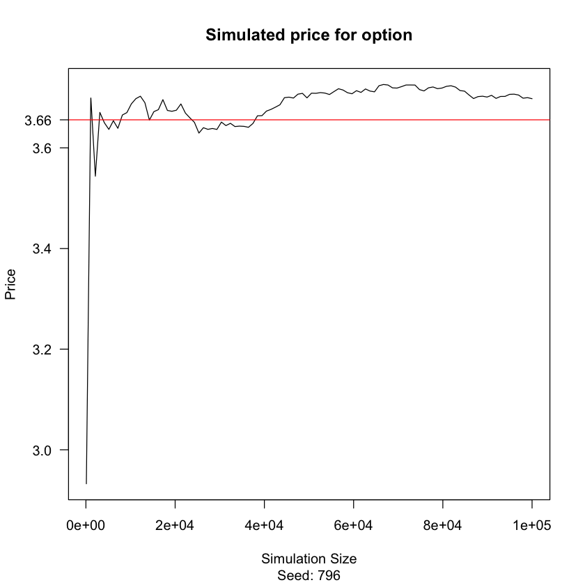

```r
seed <- sample(100:999,1)

# Simulation price of each
P_sim <- sapply(x, Sim, seed = seed, message = FALSE)

# Plot
plot(x, P_sim, type = "l", main = "Simulated price for option", sub = paste0("Seed: ", seed),
    xlab = "Simulation Size", ylab = "Price", las = 1)

# Add horizontal line on Analytic price
abline(h = put, col = "red")
axis(2, at = put, label = round(put,2), las = 1)
```

## Analytical and simulations method for VaR

Let's first find the VaR of the stock using a simulation:

```r
# Simulating arithmetic returns

# Specifying VaR probability
probability <- 0.01

# Sample standard deviation
sigma <- sd(y)

# Number of simulations
S <- 1e3

# Set a seed
seed <- 456
set.seed(seed)

# Draw from a normal distribution, using daily rate and standard deviation
ysim <- rnorm(S, mean = r/365, sd = sigma)

# Simulate prices
Psim <- P*(1+ysim)

# Sort the simulated profit/loss
q <- sort(Psim - P)

# VaR from quantile
VaR1s <- -q[ceiling(probability*S)]

# Round
round(VaR1s,2)
```

7.47

We can compare it with the analytical VaR:

```r
# Analytical VaR
VaR1t <- abs(sigma*qnorm(probability)*P)
round(VaR1t,2)
```

7.6

### Larger simulation size

Instead of using 1000 simulations, we can see if a larger number gets us closer to the analytical price:

```r
# Function that computes simulation VaR for a number of simulations and seed
simVaR <- function(S, seed = 999, message = TRUE) {
    # Include elapsed time
    old <- Sys.time()

    set.seed(seed)
    ysim <- rnorm(S, mean = r/365, sd = sigma)
    Psim <- P*(1+ysim)
    q <- sort(Psim - P)
    VaR1s <- -q[ceiling(probability*S)]
    if (message) {
        cat("Number of simulations", S, "\n")
        cat("Elapsed time:", difftime(Sys.time(), old, units = "secs"), "seconds")
    }

    return(VaR1s)
}

round(simVaR(S = 1e4, seed = seed),2)
round(simVaR(S = 1e6, seed = seed),2)
```

```
Number of simulations 10000
Elapsed time: 0.002403021 seconds
```

7.37

```
Number of simulations 1e+06
Elapsed time: 0.131144 seconds
```

7.6

Creating a plot:

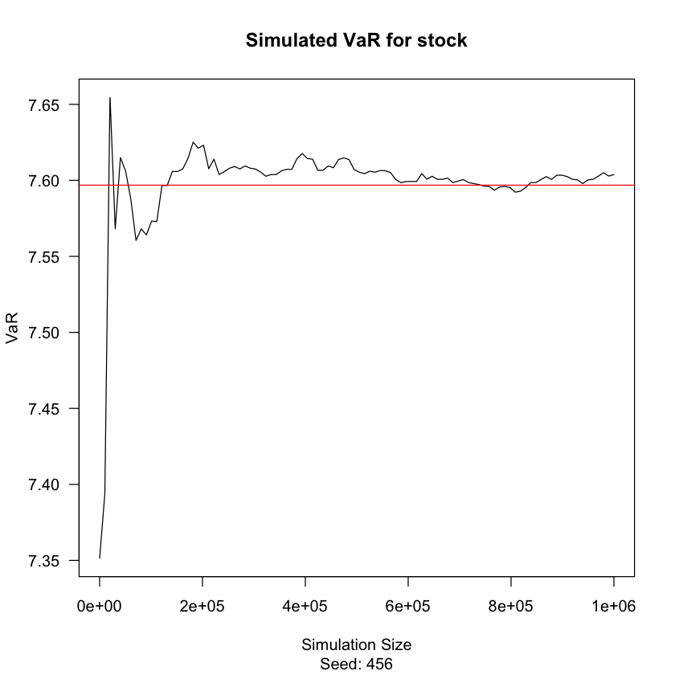

```r
# Plotting

# Sequence of simulations
x <- seq(100, 1000000, length = 100)

# Simulation VaR of each
VaR_sim <- sapply(x, simVaR, seed = seed, message = FALSE)

# Plot
plot(x, VaR_sim, type = "l", main = "Simulated VaR for stock", sub = paste0("Seed: ", seed),
    xlab = "Simulation Size", ylab = "VaR", las = 1)

# Add horizontal line on Analytic VaR
abline(h = VaR1t, col = "red")
```

## Calculating VaR for the option

To calculate the VaR for the option we can apply the Black-Scholes formula using the observed price and the simulated prices, and a sigma scaled for the yearly trading days:

```r
# VaR for the option

# Calculate put
put <- bs(K = K, P = P, r = r, sigma = sqrt(sigma^2 * 250), Maturity = Maturity)

# Simulate prices
S <- 1e3
set.seed(444)
ysim <- rnorm(S, mean=r/365, sd=sigma)
Psim <- P*(1+ysim)

# Use simulated prices in Black-Scholes formula
fsim <- bs(K=K, P=Psim, r=r, sigma=sqrt(sigma^2 *250), Maturity = Maturity-(1/365))

# Sort the vector
q <- sort(fsim - put)

# Get the value that meets the VaR probability
VaR2 <- -q[ceiling(probability*S)]
round(VaR2,3)
```

0.824

## Calculating VaR for a portfolio of stock and option

If we have a portfolio that has both an option and the underlying stock, we can calculate VaR as follows:

```r
# VaR for a portfolio

# Assets
xb <- 3
xo <- 2

# Create portfolio
portfolio_today <- xb*P + xo*put
round(portfolio_today)
```

426

Use the vector of simulated prices, `Psim`, to calculate tomorrow's value of the portfolio:

```r
# Calculating tomorrow's value of the portfolio
option_tomorrow <- bs(K = K, P = P, r = r, sigma = sqrt(sigma^2 * 250), Maturity = Maturity - (1/365))
portfolio_tomorrow <- xb*Psim + xo*option_tomorrow
```

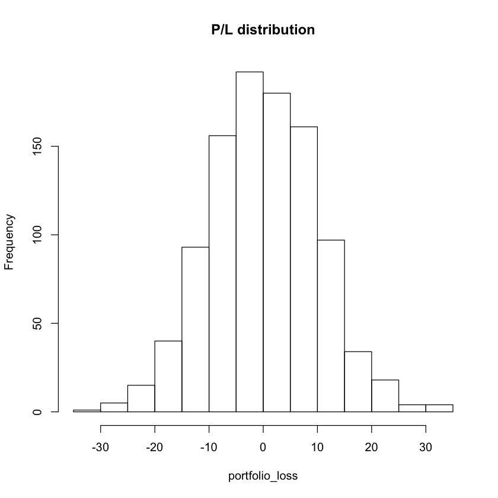

```r
# Find the profit-loss
portfolio_loss <- portfolio_tomorrow - portfolio_today

# We can see its distribution
hist(portfolio_loss, main = "P/L distribution")
```

```r
# Find VaR
portfolio_loss <- sort(portfolio_loss)
portfolio_VaR <- -portfolio_loss[ceiling(S*probability)]
round(portfolio_VaR,2)
```

23.09

We can include a new option, with a different strike price, and see how it changes our VaR:

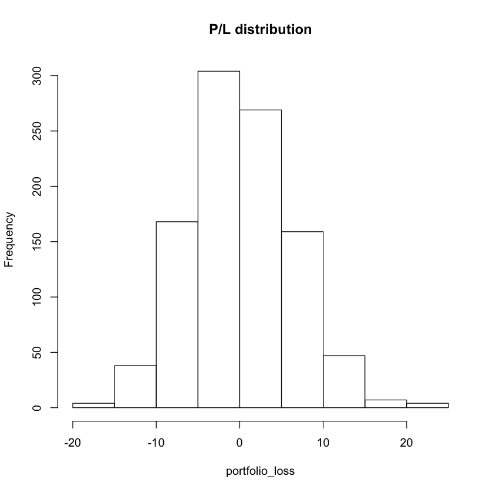

```r
# Introducing a second option
xo2 <- 15
K2 <- 90

# Get the prices using Black-Scholes
option2_today <- bs(K=K2, P=P, r=r, sigma=sqrt(sigma^2 *250), Maturity=Maturity)
option2_tomorrow <- bs(K=K2, P=Psim, r=r, sigma=sqrt(sigma^2 * 250), Maturity=Maturity-(1/365))

# Portfolio values
portfolio_today <- xb*P + xo*put + xo2*option2_today
portfolio_tomorrow <- xb*Psim + xo*option_tomorrow + xo2*option2_tomorrow

# Find the profit-loss
portfolio_loss <- portfolio_tomorrow - portfolio_today

# We can see its distribution
hist(portfolio_loss, main = "P/L distribution")
```

```r
# Find VaR
portfolio_loss <- sort(portfolio_loss)
portfolio_VaR <- -portfolio_loss[ceiling(S*probability)]
round(portfolio_VaR,2)
```

13.48

## Recap

In this seminar we have covered:

- Pricing a put option analytically with Black-Scholes
- Simulating option prices with Monte Carlo
- Evaluating convergence to analytical solutions for different simulation sizes
- Stock, option and portfolio VaR calculations

Some new functions used:

- `bs()`
- `Sim()`
- `SimVaR()`

For more discussion on the material covered in this seminar, refer to *Chapter 6: Analytical value-at-risk for options and bonds* and *Chapter 7: Simulation methods for VaR for options and bonds* on *Financial Risk Forecasting* by Jon Danielsson.

Acknowledgements: Thanks to Alvaro Aguirre for creating these notebooks  
© Jon Danielsson, 2020